# API Queries

# Goal

Our goal in this analysis is to get the age information about all members of the current congressional delegation. We can use the member_details endpoint to get detailed information about a member, but we need to know a members `bioguideId` in order to get their year of birth, so we’re actually going to need to send queries to multiple different endpoints in order to assemble this data all in one place.

Sign up for an API key here: https://api.congress.gov/sign-up/

Query documentation: https://api.congress.gov/

Detailed data documentation: https://github.com/LibraryOfCongress/api.congress.gov/tree/main/Documentation

## httr2 functions

| command | description |
| --- | --- |
| `request()` | creates a request object |
| `req_url_path_append()` | adds stuff to the URL path “appends with /” |
| `req_url_query()` | takes a named list and adds URL parameters |
| `req_perform()` | sends a prepared request. (Nothing is requested until you run this function!) |
| `resp_body_json()` | takes a json formatted response and converts it to an R list. |

# Setting up the request

Start by loading the relevant libraries and creating a base URL that we can re-use. Since we’ll always need to send our API key, you can go ahead and add this as a parameter to the base URL object:

```r
library(httr2)
library(tidyverse)
# get the base URL
request = request('https://api.congress.gov/v3/')|>
  # append the API key
  req_url_query('api_key'= Sys.getenv("CONGRESS_API_KEY"))
```

We can use this code to retrieve information about the current congress:

```r
current_congress<-request|>
  req_url_path_append("congress/current")|>
  req_perform()|>
  resp_body_json()
```

## Question 1

Examine the structure of `current_congress` response and extract the number of the current congress (it should be just a number) and assign it to an object called `current_congress_number`

```r
# extracting the current congress number:
current_congress_number<-current_congress$congress$number


current_congress[[1]][[3]]
```

```
## [1] 118
```

```r
current_congress[["congress"]][["number"]]
```

```
## [1] 118
```

According to the [API documentation](https://api.congress.gov/) we can extract member information from the `member` endpoint. The query should look something like this:  
[https://api.congress.gov/v3/member/congress/118?api_key=[INSERT_KEY]](https://api.congress.gov/v3/member/congress/118?api_key=%5BINSERT_KEY%5D)

To make our code more future-proof, we can replace `118` with the `current_congress_number` variable that we created in the prior step.

```r
congress_info<-request|>
  req_url_path_append("member","congress", current_congress_number)|>
  req_url_query(limit =250)|>
  req_perform()|>
  resp_body_json()


# take a look at the first object
congress_info$members[[1]]
```

```
## $bioguideId
## [1] "M001229"
##
## $depiction
## $depiction$attribution
## [1] "Image courtesy of the Member"
##
## $depiction$imageUrl
## [1] "https://www.congress.gov/img/member/66fd489d799e1a7c06d68d62_200.jpg"
##
##
## $district
## [1] 10
##
## $name
## [1] "McIver, LaMonica"
##
## $partyName
## [1] "Democratic"
##
## $state
## [1] "New Jersey"
##
## $terms
## $terms$item
## $terms$item[[1]]
## $terms$item[[1]]$chamber
## [1] "House of Representatives"
##
## $terms$item[[1]]$startYear
## [1] 2024
##
##
##
##
## $updateDate
## [1] "2024-10-02T15:00:58Z"
##
## $url
## [1] "https://api.congress.gov/v3/member/M001229?format=json"
```

```r
congress_info$pagination
```

```
## $count
## [1] 552
##
## $`next`
## [1] "https://api.congress.gov/v3/member/congress/118?offset=250&limit=250&format=json"
```

```r
congress_list <- congress_info$members
# then create our list of offsets
offsets<-seq(from=length(congress_list),
             to = congress_info$pagination$count,
             by= 250)

# iterate over the offsets and add them as the i-th element of the list
for(i in offsets){
  next_page <-
    congress_info <- request |>
    req_url_path_append("member", "congress", current_congress_number) |>
    req_url_query(limit = 250, offset=i) |>
    req_perform() |>
    resp_body_json()

  congress_list <- c(congress_list, next_page$members)

}
```

We can extract some specific member information like this:

```r
variables<-c('name', 'state', 'partyName', 'url')

congress_list[[1]][variables]
```

```
## $name
## [1] "McIver, LaMonica"
##
## $state
## [1] "New Jersey"
##
## $partyName
## [1] "Democratic"
##
## $url
## [1] "https://api.congress.gov/v3/member/M001229?format=json"
```

## Question 2

Write a loop to iterate through values of `congress_list` and populate the empty data frame below:

```r
variables<-c('name', 'state', 'partyName', 'url')

nrows <- length(congress_list)

congress_df <- data.frame('name'=character(nrows),
                          'state' = character(nrows),
                          'partyName'=character(nrows),
                          'url'  = character(nrows)
                          )


for(i in 1:nrows){
  # member data
  member_i_data <- congress_list[[i]][variables]
  congress_df[i, ] <- member_i_data
}
```

## Question 3A

Finally, we can use the `url` columns (along with our API key) to get detailed biographical information about a member.

Write a loop that iterates through each value of `url` in `congress_df` and queries the relevant member information (you can just do the first 20 for the sake of keeping things to a reasonable time frame)

```r
#


congress_df$birthYear<-NA

for(i in 1:nrow(congress_df)){
  # send a request
  member_i_info<-request(congress_df$url[i])|>
  # append the API key
    req_url_query(api_key = Sys.getenv("CONGRESS_API_KEY"))|>
    req_perform()|>
    resp_body_json()
  # append the result to member_info
  #member_info[[i]]<- member_i_info$member$birthYear
  congress_df$birthYear[i]<-member_i_info$member$birthYear


}
```

## Question 3B

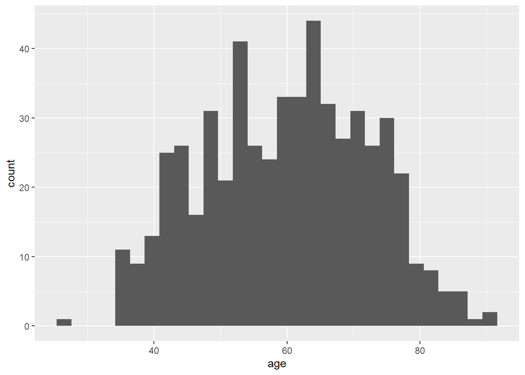

```r
# changing to numeric and subtracting the year to calculate age
congress_df$age<-year(Sys.Date()) - as.numeric(congress_df$birthYear)

ggplot(congress_df, aes(x=age)) +
  geom_histogram()
```

## Extra info: unpacking the response with enframe

Instead of writing a loop, its possible to use the `enframe()|>unnest_wider()` method I mentioned earlier here. However, you’ll get an error message about a duplicate name if you try to do it without adding any options:

```r
congress_df<-
  congress_list|>
  enframe()|>
  unnest_wider(value)
```

```
## Error in `unnest_wider()`:
## ! Can't duplicate names between the affected columns and the original
##   data.
## ✖ These names are duplicated:
##   ℹ `name`, from `value`.
## ℹ Use `names_sep` to disambiguate using the column name.
## ℹ Or use `names_repair` to specify a repair strategy.
```

The problem is that `enframe` adds a new column called “name” to the data frame, but there’s already a list element with that name in this response. So you can fix this by adding the `name='index'` option.

```r
congress_df <-
  congress_list|>
  enframe(name='index')|>
  unnest_wider(value)

head(congress_df)
```

| index | bioguideId | depiction | district | name | partyName | state | terms | updateDate | url |
| --- | --- | --- | --- | --- | --- | --- | --- | --- | --- |
| 1 | M001229 |  | 10 | McIver, LaMonica | Democratic | New Jersey |  | 2024-10-02T15:00:58Z | https://api.congress.gov/v3/member/M001229?format=json |
| 2 | H001097 |  | NA | Helmy, George S. | Democratic | New Jersey |  | 2024-09-12T12:42:19Z | https://api.congress.gov/v3/member/H001097?format=json |
| 3 | R000599 |  | 25 | Ruiz, Raul | Democratic | California |  | 2024-09-11T16:29:00Z | https://api.congress.gov/v3/member/R000599?format=json |
| 4 | D000594 |  | 15 | De La Cruz, Monica | Republican | Texas |  | 2024-09-05T19:42:02Z | https://api.congress.gov/v3/member/D000594?format=json |
| 5 | M000639 |  | NA | Menendez, Robert | Democratic | New Jersey |  | 2024-08-28T21:23:38Z | https://api.congress.gov/v3/member/M000639?format=json |
| 6 | P000096 |  | 9 | Pascrell, Bill | Democratic | New Jersey |  | 2024-08-22T13:32:48Z | https://api.congress.gov/v3/member/P000096?format=json |

We can go a step further here and do some additional unnesting on the `terms` data to get the most recent term information for each member.

```r
congress_df_wider <-
  congress_df |>
  # hoist lets us use negative indexing to get the last item in list,
  # so this only grabs the most recent term for each member:
  hoist(terms, recent_term = list('item', -1))|>
  unnest_wider(recent_term)
```

And now we can use the most recent term information to filter out members who have retired. If they’re still in Congress, then `endYear` should just be NA:

```r
current_members<-congress_df_wider|>
  filter(is.na(endYear))

nrow(current_members)
```

```
## [1] 538
```

We still won’t end up with exactly 535 members here because of vacancies and the inclusion of non-voting members from the US territories and D.C., but we will remove all the retired members from the list.

The vignette on [`rectangling`](https://tidyr.tidyverse.org/articles/rectangle.html) has some useful information on working with this kind of deeply nested data without having to resort to writing loops.